# Introduction to R for Energy Data

**Hello class!**

To start our adventure in *R*, let’s start by loading the required software software:

- [Download R](https://cloud.r-project.org/)
- [Download RStudio](http://www.rstudio.com/download)

Once you’ve done that, you want to go to RStudio and select:

- File > New File > RScript

You should now have a blank source pane in which to start writing!

Start by installing and loading packages. While R has base abilities, adding packages made by the myriad of users is what makes R so versatile. Let’s add the `tidyverse` to start, it’s a collection of important packages made by the people at RStudio. We should also add `readxl` because we are going to read in an excel file.

```r
#install.packages("tidyverse")  #this installs the package (remove the hashtag to uncomment and run this line the first time you run it)
#install.packages("readxl")  #this installs the package (remove the hashtag to uncomment and run this line the first time you run it)
#install.packages("ggthemes")  #this installs the package (remove the hashtag to uncomment and run this line the first time you run it)
#install.packages("lubridate")  #this installs the package (remove the hashtag to uncomment and run this line the first time you run it)
library(tidyverse)  #this loads the installed package
library(readxl)  #this loads the installed package
library(ggthemes)  #this loads the installed package
library(lubridate)  #this loads the installed package
```

Next, lets load in some simple data just to play around.

We will start by downloading a file from the AESO’s Data Requests page (a treasure trove of great data sets!). Once that is downloaded, we will read it into R as a dataframe object called `data`:

```r
download.file("https://aeso.ca/assets/Uploads/data-requests/System-Load-Annual-2009-to-2022.xlsx",
              destfile="annual_load.xlsx",
              mode="wb")
data <- read_xlsx("annual_load.xlsx")
```

Let’s take a peak at this data object:

```r
head(data)
```

```
## # A tibble: 6 × 3
##    Year `System Load (GWh)` ...3
##   <dbl>               <dbl> <chr>
## 1  2009               56358 <NA>
## 2  2010               57377 <NA>
## 3  2011               58681 <NA>
## 4  2012               59004 <NA>
## 5  2013               60480 <NA>
## 6  2014               62479 <NA>
```

Ok! We have data! But there’s a weird third column and i don’t like the variable names. Let’s delete the 3rd column and rename the first two. To do that we will create a new dataframe called `df` and use the `tidyverse` to make some changes:

```r
df <- data %>%   #assign data to a new object called df and then (%>%)...
  select(-3)  %>% #select all columns that are NOT column 3 and then (%>%)...
  rename(year=Year,load=`System Load (GWh)`)  #rename the columns; note the backticks, that's how you deal with variable names that have spaces.
head(df)  #let's peek at the first few rows of this new object
```

```
## # A tibble: 6 × 2
##    year  load
##   <dbl> <dbl>
## 1  2009 56358
## 2  2010 57377
## 3  2011 58681
## 4  2012 59004
## 5  2013 60480
## 6  2014 62479
```

Much nicer!

Now let’s explore the data using a quick chart. Let’s plot the annual system load by year.

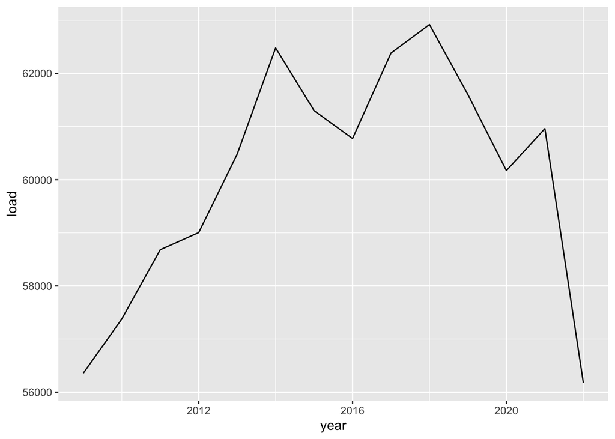

```r
ggplot(df,aes(x=year,y=load))+  #we are creating a plot using the dataframe `df` and the aesthetics will involve year on the x-axis and load on the y-axis
  geom_line()  #plot a line using the aesthetics assigned above (note we could have assigned them here as well)
```

Not bad! Our first chart!

Now let’s try a nicer looking version. Maybe a bar chart…

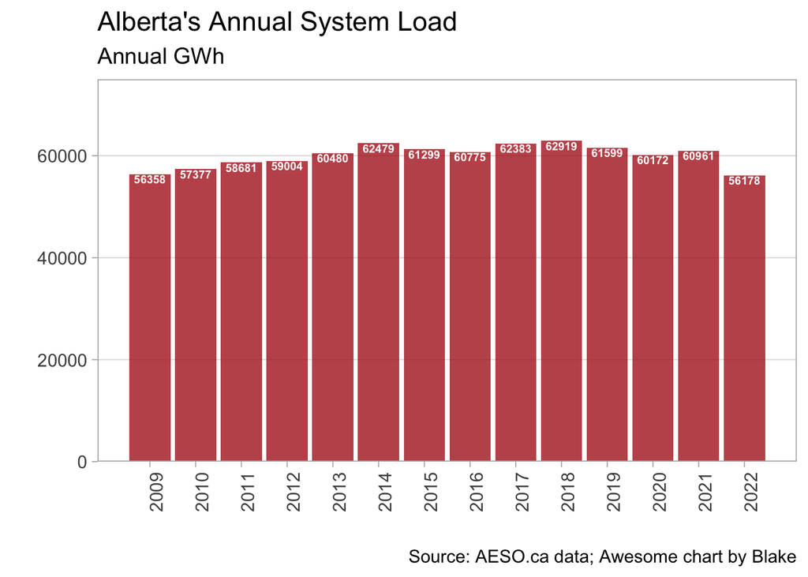

```r
ggplot(df,aes(year,load,label=load))+
  geom_col(fill="firebrick",alpha=.8)+
  geom_text(vjust=1.1,size=2.5,fontface="bold",color="white")+
  scale_x_continuous(breaks=seq(2009,2022,1))+
  scale_y_continuous(limits=c(0,75000),expand=c(0,0))+
  labs(x="",y="",
       title="Alberta's Annual System Load",
       subtitle="Annual GWh",
       caption="Source: AESO.ca data; Awesome chart by Blake")+
  theme_light(14)+
  theme(panel.grid.minor=element_blank(),
        panel.grid.major.x=element_blank(),
        axis.text.x=element_text(angle=90))
```

**Now let’s try something more…**

Let’s look at annual percentage changes.

To do this, we are going to have to calculate the percentage change as the current year value / prior year value - 1. We can use the `mutate` command and the `lag` function to do this!

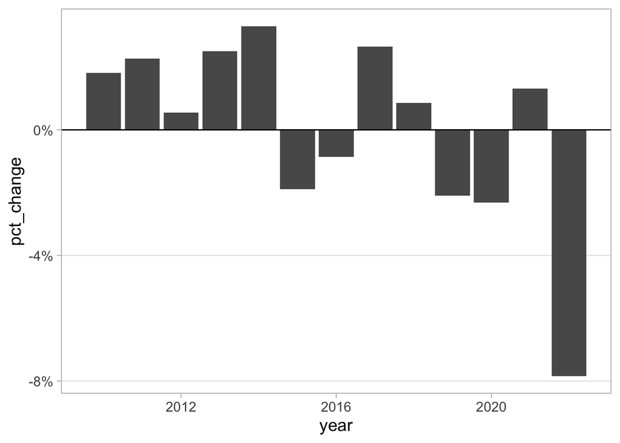

```r
df <- df %>%
  mutate(pct_change=load/lag(load)-1)

ggplot(df,aes(year,pct_change))+
  geom_col()+
  geom_hline(yintercept=0)+
  scale_y_continuous(labels=scales::percent)+
  theme_light(14)+
  theme(panel.grid.minor=element_blank(),
        panel.grid.major.x=element_blank())
```

**Now let’s try something more…**

Maybe we made it this far in class, maybe you’re doing this at home…

Let’s dig a little deeper into load data. Specifically, let’s look at monthly and even hourly shapes. To do that, you’ll have to download a different file with hourly load shapes.

It just so happens I’ve made one for you! 25 years of hourly data…

```r
download.file("https://blakeshaffer.ca/uploads/data/AIL.xlsx",
              destfile="hourly_load.xlsx",
              mode="wb")
data <- read_xlsx("hourly_load.xlsx")
```

Let’s take a peak at this data object:

```r
head(data)
```

```
## # A tibble: 6 × 2
##   Datetime          Load
##   <chr>            <dbl>
## 1 01/01/2000 00:00  5698
## 2 01/01/2000 01:00  5553
## 3 01/01/2000 02:00  5442
## 4 01/01/2000 03:00  5319
## 5 01/01/2000 04:00  5278
## 6 01/01/2000 05:00  5268
```

Ok! We have data! But there’s a problem. It read in the Datetime variable as a character.

We want to convert that to a date object using `lubridate` functionality.

```r
data <- data %>%
  mutate(Datetime=mdy_hm(Datetime))
head(data)
```

```
## # A tibble: 6 × 2
##   Datetime             Load
##   <dttm>              <dbl>
## 1 2000-01-01 00:00:00  5698
## 2 2000-01-01 01:00:00  5553
## 3 2000-01-01 02:00:00  5442
## 4 2000-01-01 03:00:00  5319
## 5 2000-01-01 04:00:00  5278
## 6 2000-01-01 05:00:00  5268
```

Looks the same but note that now Datetime is a `POSIXct` variable, which is Date-time for lubridate. That’s good!

Now we can do some slicing and dicing!

Let’s start by creating year and month averages. To do this we will use `mutate`, `group_by` and `summarise`. I’ll create a new dataframe to preserve the raw data.

```r
df <- data %>%
  mutate(year=year(Datetime),
         month=month(Datetime)) %>%
  group_by(year,month) %>%
  summarise(Load=mean(Load))
```

Rather than a time series plot, let’s plot by month with different colored lines for the years!

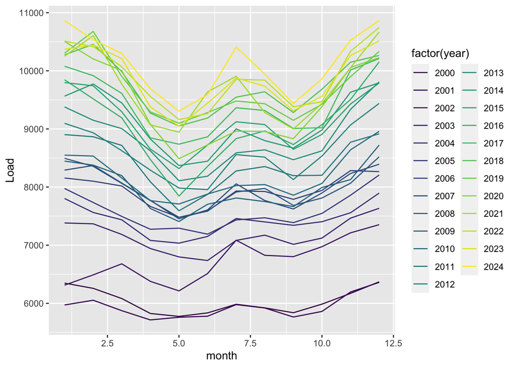

```r
ggplot(df, aes(month,Load,color=factor(year)))+
  geom_line()+
  scale_color_viridis_d()
```

Let’s try hourly shapes and use the `facet_wrap` feature. Let’s look only at 2024 data and get hourly averages by month, plotting each month in a mini-plot.

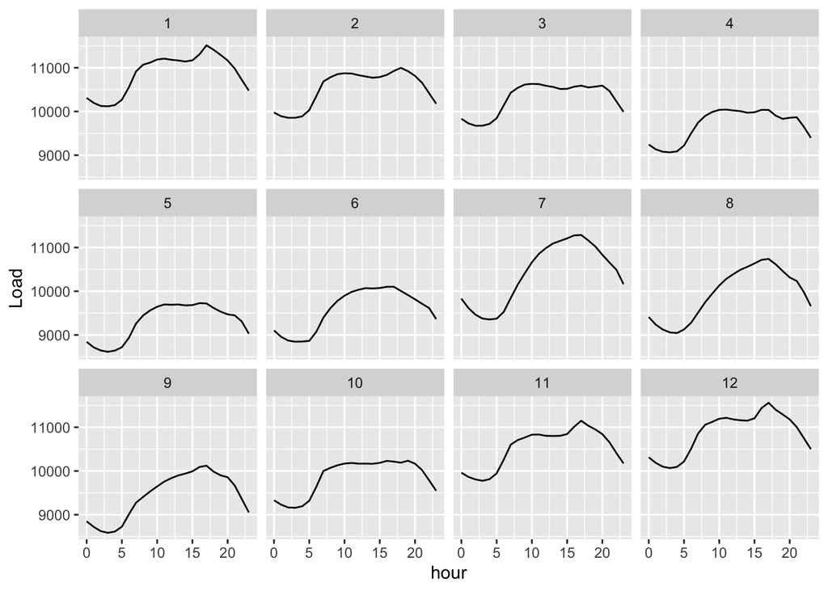

```r
df.hourly <- data %>%
  filter(year(Datetime)==2024) %>%
  mutate(hour=hour(Datetime),
         month=month(Datetime)) %>%
  group_by(hour,month) %>%
  summarise(Load=mean(Load))

ggplot(df.hourly, aes(hour,Load))+
  facet_wrap(~month)+
  geom_line()
```

Last thing! Let’s see if we can see some effect from rooftop solar in Alberta.

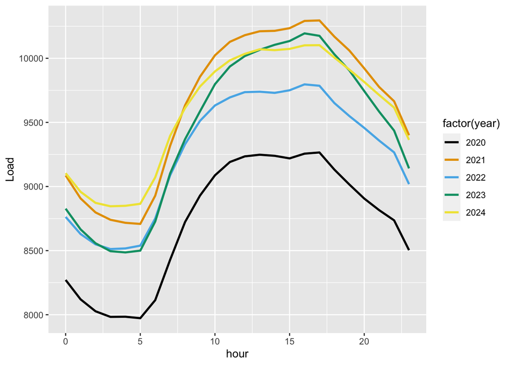

```r
df.june <- data %>%
  filter(month(Datetime)==6) %>%
  mutate(hour=hour(Datetime),
         year=year(Datetime)) %>%
  group_by(hour,year) %>%
  summarise(Load=mean(Load))

ggplot(df.june %>% filter(year>=2020), aes(hour,Load,color=factor(year)))+
  geom_line(size=1)+
  scale_color_colorblind()
```

**More tips for R and data vizualization**

For more tips on learning R and creating charts using `ggplot`, I highly recommend the free e-book [R for Data Science](https://r4ds.had.co.nz/) by Hadley Wickham. It starts from zero and takes you to producing creative charts very quickly. You may want to explore the `ggthemes` package, which has some nice preset themes to change the appearance of the chart.

A great resource for good data visualization (IMHO) is Claus Wilke’s (free) e-book [Fundamentals of Data Visualization](https://clauswilke.com/dataviz/).